# Data Processing

### Load Libraries

```python
import pandas as pd
from sklearn.model_selection import train_test_split, cross_val_score, RepeatedKFold
import matplotlib.pyplot as plt
import numpy as np
from sklearn.pipeline import Pipeline
from sklearn import preprocessing
from sklearn.preprocessing import StandardScaler, MaxAbsScaler, MinMaxScaler, LabelEncoder
import json
import lightgbm as lgbm
from sklearn.decomposition import PCA
from sklearn.manifold import TSNE
import seaborn as sns
from imblearn.over_sampling import RandomOverSampler
from sklearn.svm import SVC
from sklearn.ensemble import RandomForestClassifier, GradientBoostingClassifier
from sklearn.metrics import mean_squared_error, confusion_matrix, accuracy_score
from mlxtend.plotting import plot_confusion_matrix
```

### Load Data

```python
df = pd.read_csv("T_ONTIME_REPORTING.csv")
df.head()
```

|  | YEAR | MONTH | DAY_OF_MONTH | DAY_OF_WEEK | OP_UNIQUE_CARRIER | ORIGIN | DEST | DEP_DELAY_NEW | DELAY_INDICATOR | CANCELLED | INDICATOR |
| --- | --- | --- | --- | --- | --- | --- | --- | --- | --- | --- | --- |
| 0 | 2022 | 1 | 14 | 5 | YX | CMH | DCA | 0.0 | 0 | 0 | 0 |
| 1 | 2022 | 1 | 15 | 6 | YX | CMH | DCA | 0.0 | 0 | 0 | 0 |
| 2 | 2022 | 1 | 16 | 7 | YX | CMH | DCA | 0.0 | 0 | 0 | 0 |
| 3 | 2022 | 1 | 17 | 1 | YX | CMH | DCA | 0.0 | 0 | 0 | 0 |
| 4 | 2022 | 1 | 18 | 2 | YX | CMH | DCA | 0.0 | 0 | 0 | 0 |

```python
print(df.shape)
```

```
(537902, 11)
```

```python
df.OP_UNIQUE_CARRIER.unique()
```

```
array(['YX', 'OO', 'UA', 'YV', 'OH', 'QX', 'WN', 'DL', 'F9', 'G4', 'HA',
       'MQ', 'NK', '9E', 'AA', 'AS', 'B6'], dtype=object)
```

### Remove the indicator columns "DELAY_INDICATOR" and "CANCELLED" as those are counted for in the INDICATOR column. Also using LabelEncoder to encode the the variables that are strings (Airport Code, Airport Codes, etc.). Since the year and month are the same for all the records, those columns will be dropped as well.

```python
df.drop(columns=["DELAY_INDICATOR","CANCELLED","YEAR", "MONTH"],inplace=True)
le = preprocessing.LabelEncoder()
df['OP_UNIQUE_CARRIER'] = le.fit_transform(df['OP_UNIQUE_CARRIER'])
df['ORIGIN'] = le.fit_transform(df['ORIGIN'])
df['DEST'] = le.fit_transform(df['DEST'])
```

### Checking for null and NaN values.

```python
df.isnull().sum()
```

```
DAY_OF_MONTH             0
DAY_OF_WEEK              0
OP_UNIQUE_CARRIER        0
ORIGIN                   0
DEST                     0
DEP_DELAY_NEW        32914
INDICATOR                0
dtype: int64
```

Since all the NaN/null values come from flights that have been cancelled (no depart time information). Filling those null values with 0's.

```python
for index, row in df.iterrows():
    if row['INDICATOR']==2:
        df.at[index,'DEP_DELAY_NEW']=0
```

Checking to make sure that all the NaN/null values are filled.

```python
df.isnull().values.any()
```

```
False
```

```python
df.isna().values.any()
```

```
False
```

#### Even though there is no missing data, I will still "drop" rows that are missing the indicator (for good practice).

```python
df = df[df['INDICATOR']>=0]
```

```python
df.INDICATOR.value_counts()
```

```
0    328470
1    176176
2     33256
Name: INDICATOR, dtype: int64
```

61.07% of the flights were on-time  
32.75% of the flights were delayed  
6.18% of the flights were cancelled

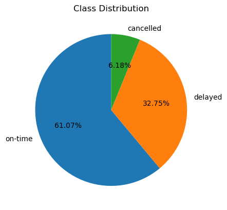

```python
plt.pie(df.INDICATOR.value_counts(), startangle=90, autopct='%1.2f%%', labels=['on-time','delayed','cancelled'])
plt.title("Class Distribution")
plt.show()
```

```python
df.OP_UNIQUE_CARRIER.value_counts()
```

```
14    97436
1     69400
4     68963
11    63146
13    45741
16    27261
8     22205
0     21644
3     21332
10    20541
9     17554
2     16549
5     12039
15    11404
6      8714
12     8105
7      5868
Name: OP_UNIQUE_CARRIER, dtype: int64
```

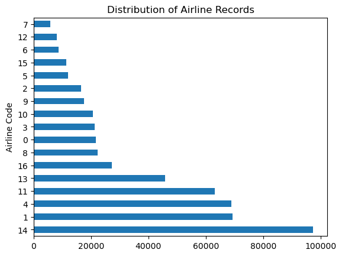

```python
df.OP_UNIQUE_CARRIER.value_counts().plot(title="Distribution of Airline Records",kind='barh',xlabel="Airline Code")
```

```
Airline 16:
	On-Time: 18036
	Delayed: 6357
	Cancelled: 2868
```

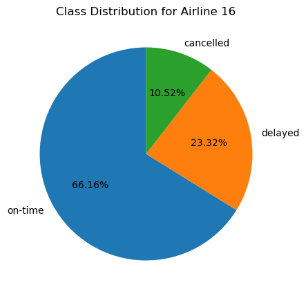

```
Airline 11:
	On-Time: 39887
	Delayed: 18975
	Cancelled: 4284
```

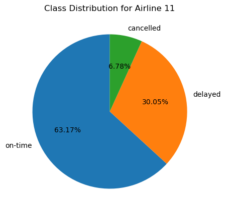

```
Airline 13:
	On-Time: 24545
	Delayed: 18290
	Cancelled: 2906
```

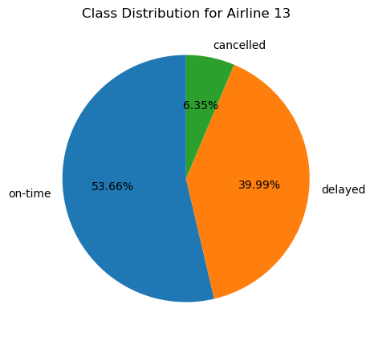

```
Airline 15:
	On-Time: 6313
	Delayed: 3635
	Cancelled: 1456
```

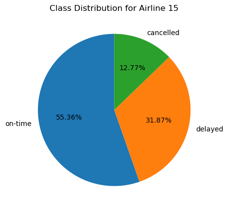

```
Airline 10:
	On-Time: 12352
	Delayed: 5947
	Cancelled: 2242
```

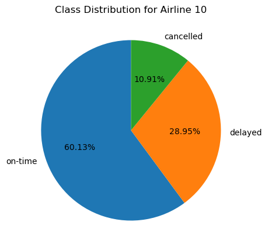

```
Airline 12:
	On-Time: 4562
	Delayed: 3117
	Cancelled: 426
```

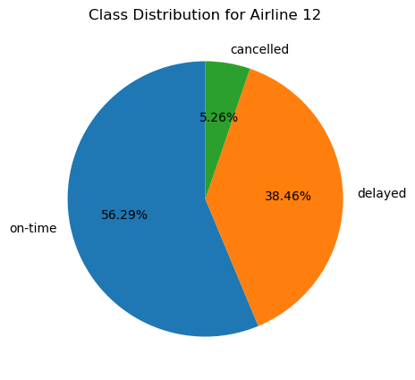

```
Airline 14:
	On-Time: 51370
	Delayed: 39618
	Cancelled: 6448
```

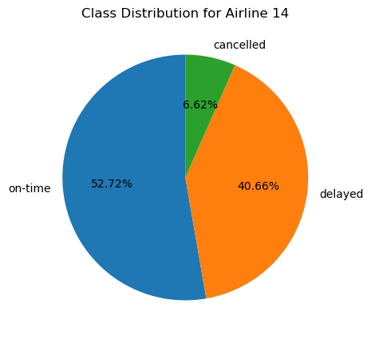

```
Airline 4:
	On-Time: 45824
	Delayed: 20902
	Cancelled: 2237
```

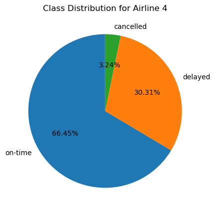

```
Airline 5:
	On-Time: 6876
	Delayed: 4627
	Cancelled: 536
```

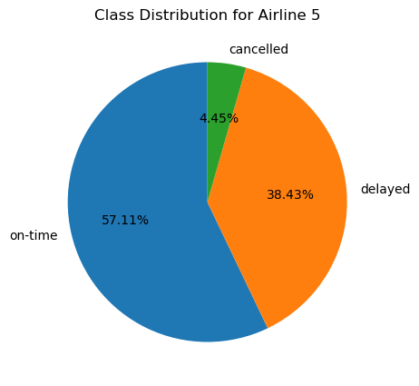

```
Airline 6:
	On-Time: 4872
	Delayed: 3118
	Cancelled: 724
```

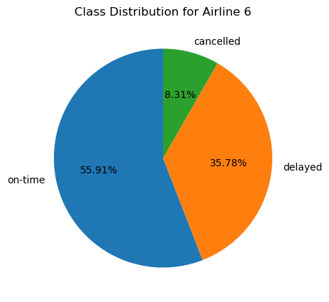

```
Airline 7:
	On-Time: 3332
	Delayed: 2319
	Cancelled: 217
```

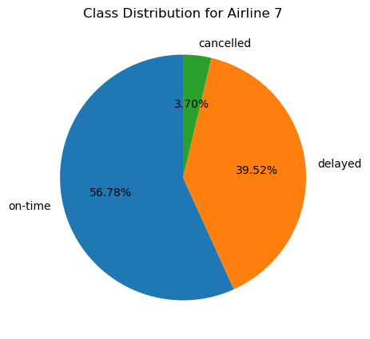

```
Airline 8:
	On-Time: 15974
	Delayed: 5562
	Cancelled: 669
```

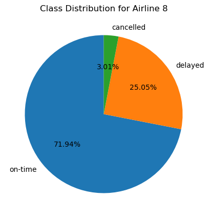

```
Airline 9:
	On-Time: 11068
	Delayed: 5885
	Cancelled: 601
```

[5 more figures not shown]

```python
def countX(lst, x):
    count = 0
    for ele in lst:
        if (ele == x):
            count = count + 1
    return count

cols = df.OP_UNIQUE_CARRIER.unique()

for col in cols:
    testList = df[df['OP_UNIQUE_CARRIER']==col]
    ot = countX(testList.INDICATOR, 0)
    delay = countX(testList.INDICATOR, 1)
    canc = countX(testList.INDICATOR, 2)
    piedata = [ot,delay,canc]
    print("Airline %s:\n\tOn-Time: %d\n\tDelayed: %d\n\tCancelled: %d\n\t"%(col, ot,delay,canc))
    plt.figure(figsize=(5,5))
    plt.pie(piedata, startangle=90, autopct='%1.2f%%', labels=['on-time','delayed','cancelled'])
    plt.title("Class Distribution for Airline %s" % col)
    plt.show()
```

```python
Y = df.INDICATOR.values
X = df.drop(columns='INDICATOR',inplace=False).copy()
Y.shape
```

```
(537902,)
```

## Applying Different ML Classification methods, scaling using StandardScaler()

```python
x_train,x_test,y_train,y_test = train_test_split(X,Y, test_size=0.25, random_state=42)

sc = StandardScaler()
sc.fit(x_train)
x_train = sc.transform(x_train)
x_test = sc.transform(x_test)
```

### Basline Model, default logistic regression (with max_iter being increased to allow the method to converge)

```
0.926001665724739
```

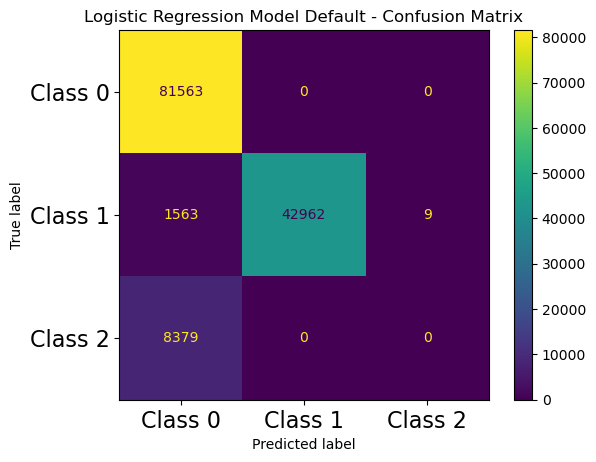

```
[0.92170885 0.92170788 0.92146    0.92146    0.92067918]
CPU times: user 1min 19s, sys: 1.8 s, total: 1min 21s
Wall time: 11.7 s
```

```python
%%time
from sklearn.linear_model import LogisticRegression
clf=LogisticRegression(max_iter=10000)
clf.fit(x_train,y_train)
print(clf.score(x_test,y_test))
from sklearn.metrics import ConfusionMatrixDisplay
cm = ConfusionMatrixDisplay.from_estimator(clf, x_test, y_test)
#plt.figure()
#plot_confusion_matrix(cm, figsize=(12,8), hide_ticks=True, cmap=plt.cm.Blues)
plt.title("Logistic Regression Model Default - Confusion Matrix")
plt.xticks(range(3), ["Class 0","Class 1","Class 2"], fontsize=16)
plt.yticks(range(3), ["Class 0","Class 1","Class 2"], fontsize=16)
plt.show()
scores_log=cross_val_score(clf,x_train,y_train,cv=5)
print(scores_log)
```

### Logistic Regression with solver 'sag'

#### Cross validation using cv=5

```
0.9241351616645349
```

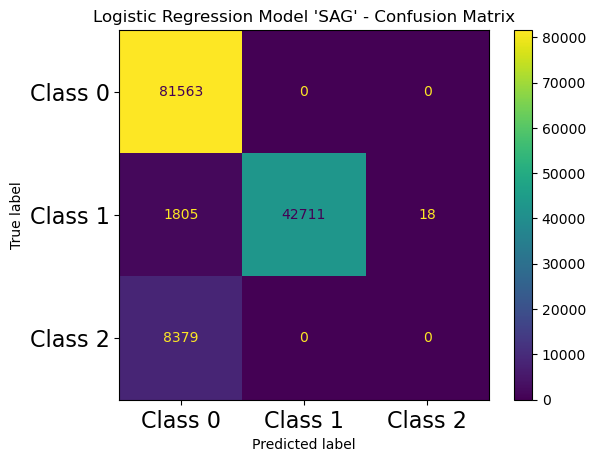

```
[0.92064299 0.9212617  0.92082791 0.92079073 0.92007188]
CPU times: user 1min 24s, sys: 1.48 s, total: 1min 25s
Wall time: 33min 14s
```

```python
%%time
from sklearn.linear_model import LogisticRegression
clf=LogisticRegression(max_iter=10000, solver='sag',n_jobs=-1)
clf.fit(x_train,y_train)
print(clf.score(x_test,y_test))
from sklearn.metrics import ConfusionMatrixDisplay
cm = ConfusionMatrixDisplay.from_estimator(clf, x_test, y_test)
#plt.figure()
#plot_confusion_matrix(cm, figsize=(12,8), hide_ticks=True, cmap=plt.cm.Blues)
plt.title("Logistic Regression Model 'SAG' - Confusion Matrix")
plt.xticks(range(3), ["Class 0","Class 1","Class 2"], fontsize=16)
plt.yticks(range(3), ["Class 0","Class 1","Class 2"], fontsize=16)
plt.show()
scores_log=cross_val_score(clf,x_train,y_train,cv=5)
print(scores_log)
#print("Mean score: %0.2f",scores_log.mean())
```

### Logistic Regression with solver 'saga'

#### Cross validation using cv=5

```
0.9223727654005176
```

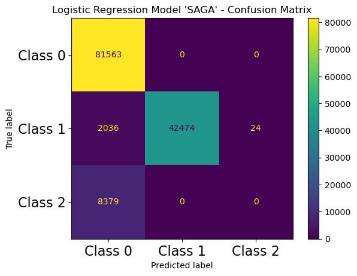

```
[0.92020921 0.92090227 0.920233   0.92029497 0.91974964]
CPU times: user 2min 19s, sys: 1.05 s, total: 2min 20s
Wall time: 10min 20s
```

```python
%%time
from sklearn.linear_model import LogisticRegression
from sklearn.metrics import ConfusionMatrixDisplay
clf=LogisticRegression(max_iter=10000, solver='saga', n_jobs=-1)
clf.fit(x_train,y_train)
print(clf.score(x_test,y_test))
cm = ConfusionMatrixDisplay.from_estimator(clf, x_test, y_test)
#plt.figure()
#plot_confusion_matrix(cm, figsize=(12,8), hide_ticks=True, cmap=plt.cm.Blues)
plt.title("Logistic Regression Model 'SAGA' - Confusion Matrix")
plt.xticks(range(3), ["Class 0","Class 1","Class 2"], fontsize=16)
plt.yticks(range(3), ["Class 0","Class 1","Class 2"], fontsize=16)
plt.show()
scores_log=cross_val_score(clf,x_train,y_train,cv=5)
print(scores_log)
```

### KNN Classifier

```python
from sklearn.neighbors import KNeighborsClassifier
from sklearn import metrics
scores = []
for k in range(1,30):
    knn = KNeighborsClassifier(n_neighbors=k, n_jobs=-1)
    knn.fit(x_train,y_train)
    y_pred=knn.predict(x_test)
    #print("K: ",k,"Train Score: ",knn.score(x_train,y_train), "Test Score: ",knn.score(x_test,y_test))
    scores.append(knn.score(x_test,y_test))
print("Best K Score: ",max(scores))
print("Best K Value: ",scores.index(max(scores))+1)
```

```
Best K Score:  0.8635295517415748
Best K Value:  1
```

### KNN Classifier using best K value from above

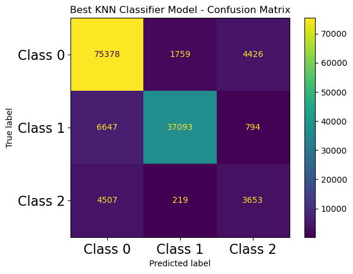

```python
knn_best = KNeighborsClassifier(n_neighbors=scores.index(max(scores))+1)
knn_best.fit(x_train,y_train)
knn_best.score(x_test,y_test)
cm = ConfusionMatrixDisplay.from_estimator(knn_best, x_test, y_test)
#plt.figure()
#plot_confusion_matrix(cm, figsize=(12,8), hide_ticks=True, cmap=plt.cm.Blues)
plt.title("Best KNN Classifier Model - Confusion Matrix")
plt.xticks(range(3), ["Class 0","Class 1","Class 2"], fontsize=16)
plt.yticks(range(3), ["Class 0","Class 1","Class 2"], fontsize=16)
plt.show()
```

```python
knn_best.score(x_test,y_test)
```

```
0.8635295517415748
```

#### Cross validation using cv=5

```python
k_scores = []
for k in range(1,30):
    knn = KNeighborsClassifier(n_neighbors=k,n_jobs=-1)
    scores = cross_val_score(knn, x_train, y_train, cv=5, scoring='accuracy')
    k_scores.append(scores.mean())
print(k_scores)
```

[output not shown]

```python
print(max(k_scores))
```

```
0.8564594217462498
```

## More advanced ML Classification Models

### Starting with XGBClassifier

```python
import xgboost as xgb
learning_rates = [0.05, 0.1, 0.25, 0.5, 0.75, 1]
xgbscores = []
for lr in learning_rates:
    xgb_clf = xgb.XGBClassifier(max_depth=10, n_estimators=100, learning_rate=lr)
    xgb_clf.fit(x_train, y_train)
    y_pred = xgb_clf.predict(x_test)
    xgbscores.append(xgb_clf.score(x_test,y_test))
    print(xgb_clf.score(x_test,y_test))
print("Best learning rate is ",learning_rates[xgbscores.index(max(xgbscores))]," with a score of ",max(xgbscores))
```

```
0.9521327225675957
0.9535233052738035
0.9536720306969273
0.952184776465689
0.9497977334245515
0.9473809452987894
Best learning rate is  0.25  with a score of  0.9536720306969273
```

### Light GBM

The reason for choosing this model is because it has a faster training speed and has better accuracy than other boosting algorithms, but MAINLY because it is able to handle large datasets with relative ease.

```python
import lightgbm as lgbm

learning_rates = [0.05, 0.1, 0.25, 0.5, 0.75, 1]
lgbmscores = []
for lr in learning_rates:
    lgbm_clf=lgbm.LGBMClassifier(num_leaves=100,n_estimators=100,max_depth=10,learning_rate=lr)
    lgbm_clf.fit(x_train,y_train)
    print(lgbm_clf.score(x_test,y_test))
    lgbmscores.append(lgbm_clf.score(x_test,y_test))
print("Best learning rate is ",learning_rates[lgbmscores.index(max(lgbmscores))]," with a score of ",max(lgbmscores))
```

```
0.9517237276540051
0.9532630357833368
0.9537612659508017
0.9429043100627621
0.6865537344953746
0.6036541836461524
Best learning rate is  0.25  with a score of  0.9537612659508017
```

```python
from sklearn.ensemble import HistGradientBoostingClassifier
learning_rates = [0.05, 0.1, 0.25, 0.5, 0.75, 1]
histscores = []
for lr in learning_rates:
    hist_clf=HistGradientBoostingClassifier(learning_rate=lr)
    hist_clf.fit(x_train,y_train)
    print(hist_clf.score(x_test,y_test))
    histscores.append(hist_clf.score(x_test,y_test))
print("Best learning rate is ",learning_rates[histscores.index(max(histscores))]," with a score of ",max(histscores))
```

```
0.949812605966864
0.9511808798596032
0.9503033998631726
0.9456482941193968
0.925302656236057
0.7522383176180136
Best learning rate is  0.1  with a score of  0.9511808798596032
```

```python
from sklearn.linear_model import SGDClassifier

SGD_clf= SGDClassifier(n_jobs=-1,loss='log_loss')
SGD_clf.fit(x_train, y_train)
print(SGD_clf.score(x_test,y_test))
```

```
0.8889764716380618
```

```python
from sklearn.ensemble import AdaBoostClassifier
clf = AdaBoostClassifier(n_estimators=100, random_state=42)
clf.fit(x_train,y_train)
clf.score(x_test,y_test)
```

```
0.937341979237931
```

## Finetuning Light GBM

Changing learning rates, bagging_fraction, and bagging frequency. There's going to be a lot of output, so I will also be storing the output to a file to read from.

```python
import lightgbm as lgbm

outputFile = open("LGBM_output.txt","w")

learning_rates = [0.05, 0.1, 0.25, 0.5, 0.75, 1]
bagging_fractions = [.1,.2,.3,.4,.5,.6,.7,.8,.9]
bagging_frequency = [5,10,15,20]
lgbmscores = []
leaves=10

for lr in learning_rates:
    for bfrac in bagging_fractions:
        for bfre in bagging_frequency:
            lgbm_clf=lgbm.LGBMClassifier(num_leaves=leaves,n_estimators=100,max_depth=10,learning_rate=lr, bagging_fraction=bfrac, bagging_freq=bfre)
            lgbm_clf.fit(x_train,y_train)
            lgbmscores.append(lgbm_clf.score(x_test,y_test))
            leaves = leaves+10
            #print("Frequency: ",bfre,"\tFraction: ",bfrac,"\tLearning Rate: ",lr,"\tScore: ",lgbm_clf.score(x_test,y_test))
            outputString = "Frequency: "+str(bfre)+"\tFraction: "+str(bfrac)+"\tLearning Rate: "+str(lr)+"\tScore: "+str(lgbm_clf.score(x_test,y_test))
            outputFile.write(outputString)
            outputFile.write('\n')
#print("Best learning rate is ",learning_rates[lgbmscores.index(max(lgbmscores))]," with a score of ",max(lgbmscores))
outputFile.close()
```

[output not shown]

[output cut: 377 more lines]

[output not shown]